# Project: California COVID-19 Data EDA and Univariate Models

jeysenbach

7/20/2020

```r
knitr::opts_chunk$set(echo = TRUE)
library(tidyverse)
library(tswge)
library(ggthemes)
```

```r
#Import Data obtained from ca.gov
CA <- read.csv("https://raw.githubusercontent.com/JaclynCoate/6373_Time_Series/master/TermProject/Data/CA_COVID_7.16.20.csv", header = T)
#Re-format Date
CA$date <- as.Date(CA$date, format = "%m/%d/%Y")
head(CA)
```

```
##         date newtested testedtotal newcountconfirmed totalcountconfirmed
## 1 2020-03-18      6291        6291               675                 675
## 2 2020-03-19      5196       11487               331                1006
## 3 2020-03-20      1041       12528               218                1224
## 4 2020-03-21       939       13467               244                1468
## 5 2020-03-22       850       14317               265                1733
## 6 2020-03-23      1237       15554               222                1955
##   newpospercent pospercent_14dayavg newcountdeaths totalcountdeaths
## 1          10.7                10.7             15               15
## 2           6.4                 8.8              3               18
## 3          20.9                 9.8              4               22
## 4          26.0                10.9              4               26
## 5          31.2                12.1              9               35
## 6          17.9                12.6              2               37
##   hospitalized_covid_confirmed_patients hospitalized_suspected_covid_patients
```

[output cut: 20 more lines]

### California: Available Variables

1. *Date* - Official reporting began 3/18/20. Hospitalization reporting began 3/29/20.
2. *newtested* - New tests each day
3. *testedtotal* - Cumulative total tests
4. *newcountconfirmed* - New positive tests each day
5. *totalcountconfirmed* - Cumulative total positive tests
6. *newpospercent* - Positive Percent: New daily positive tests divided by new daily tests
7. *pospercent_14dayavg* - Rolling average of last 2 weeks of positive percent
8. *newcountdeaths* - New deaths each day of confirmed cases
9. *totalcountdeaths* - Cumulative total deaths
10. *hospitalized_covid_confirmed_patients* - Currently hospitalized patients with positive tests
11. *hospitalized_suspected_covid_patients* - Currently hospitalized patients with symptoms but not tested
12. *hospitalized_covid_patients* - Hospitalized patients with confirmed + suspected cases
13. *all_hospital_beds* - Total available hospital beds
14. *icu_covid_confirmed_patients* - Patients with positive tests in intensive care
15. *icu_suspected_covid_patients* - Patients with symptoms but not tested in intensive care
16. *icu_available_beds* - Total available intensive care unit beds

### California: Plots of daily COVID-related measures

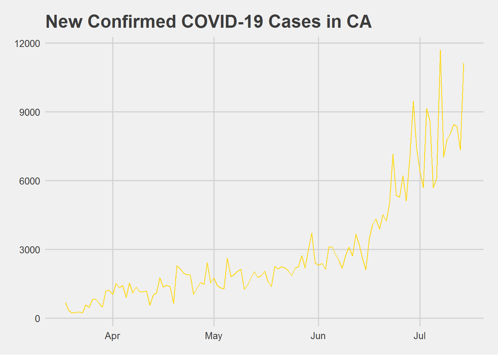

```r
#Daily New Confirmed Cases
ggplot(data=CA, aes(x=date, y=newcountconfirmed, group=1)) +
  geom_line(color="gold") + ggtitle("New Confirmed COVID-19 Cases in CA") +
  scale_x_date(date_labels = "%b") + xlab("") + ylab("Count")+ theme_fivethirtyeight()
```

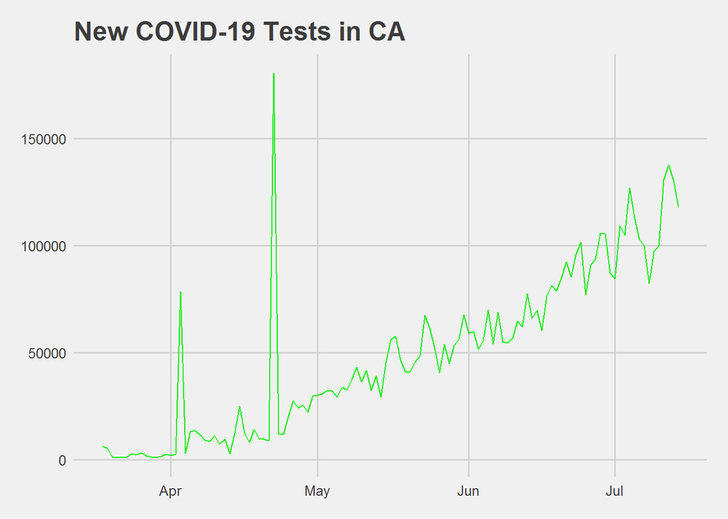

```r
#New Tests
ggplot(data=CA, aes(x=date, y=newtested, group=1)) +
  geom_line(color="green2") + ggtitle("New COVID-19 Tests in CA") +
  scale_x_date(date_labels = "%b") + xlab("") + ylab("Count")+ theme_fivethirtyeight()
```

There are 2 large spikes in test numbers; these were due to a backlog in data from San Francisco on tests administered.

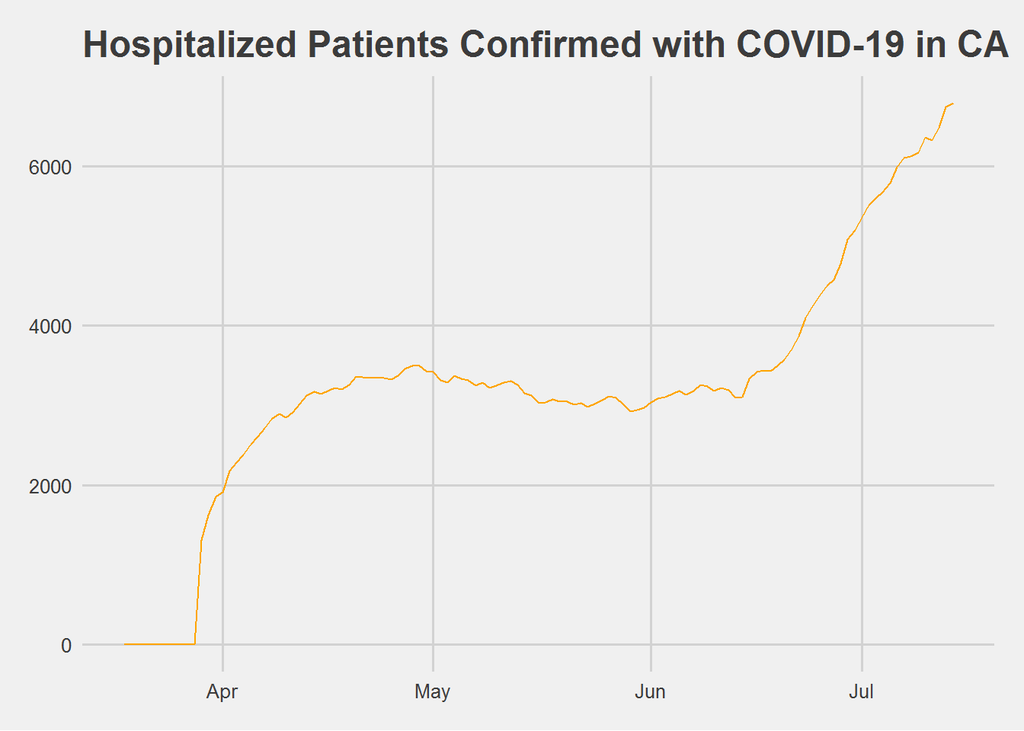

```r
#Hospitalizated Patients
ggplot(data=CA, aes(x=date, y=hospitalized_covid_confirmed_patients, group=1)) +
  geom_line(color="orange") + ggtitle("Hospitalized Patients Confirmed with COVID-19 in CA") +
  scale_x_date(date_labels = "%b") + xlab("") + ylab("Count")+ theme_fivethirtyeight()
```

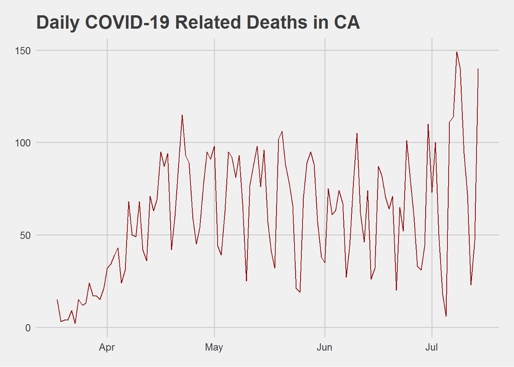

```r
#Daily Deaths
ggplot(data=CA, aes(x=date, y=newcountdeaths, group=1)) +
  geom_line(color="darkred") + ggtitle("Daily COVID-19 Related Deaths in CA") +
  scale_x_date(date_labels = "%b") + xlab("") + ylab("Count")+ theme_fivethirtyeight()
```

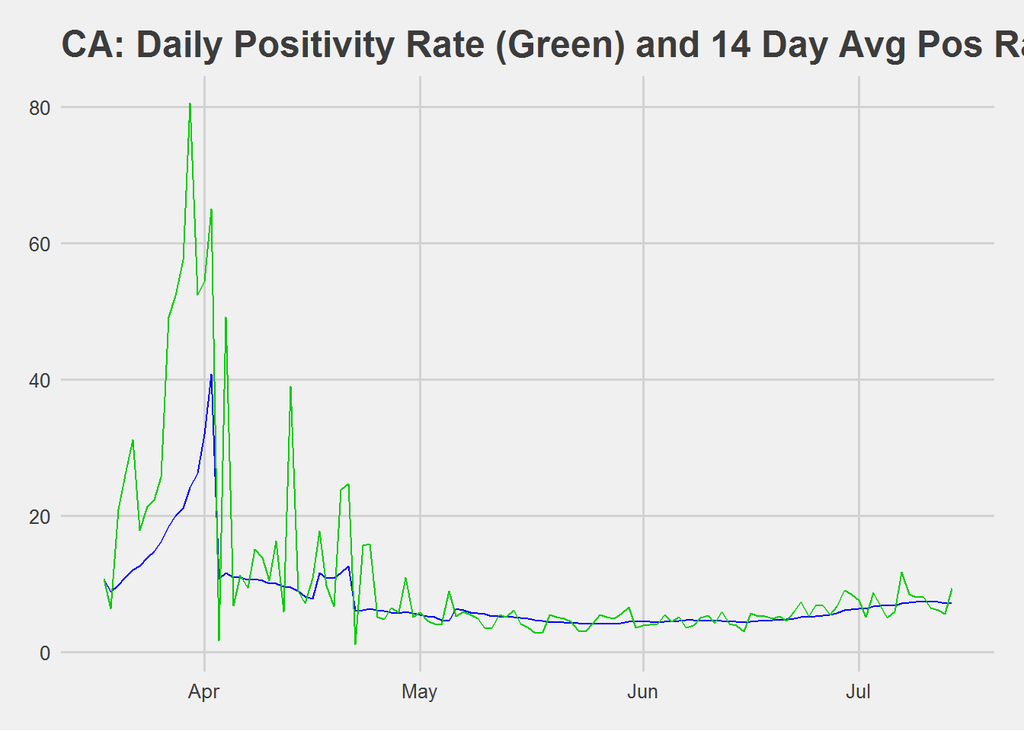

```r
#Positive Test Rate - Daily vs Avg last 2 weeks
ggplot(data=CA) +
  geom_line(data=CA,aes(x=date, y=pospercent_14dayavg), color="blue") +
  geom_line(data=CA,aes(x=date, y=newpospercent), color="green3") +
  ggtitle("CA: Daily Positivity Rate (Green) and 14 Day Avg Pos Rate (Blue)") +
  scale_x_date(date_labels = "%b") + xlab("") + ylab("Percent")+ theme_fivethirtyeight()
```

The rolling average of the past 14 days is the measure of positive percent being reported by the California state government each day. Overlaying this over the daily positive test rate, this does appear to be a good way to smooth the data in a sensible way, spreading out the effects of potential lag between tests and results as well as the changes in availability of testing at different times in the week.

### California: Plots of Cumulative Totals

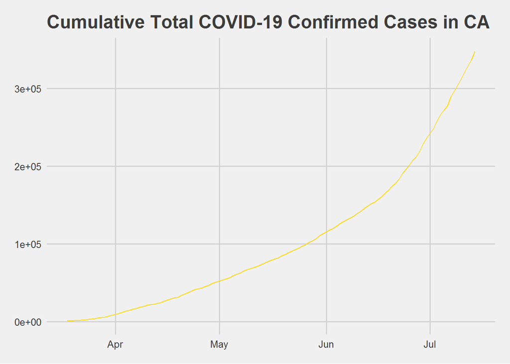

```r
#Cumulative total Cases
ggplot(data=CA, aes(x=date, y=totalcountconfirmed, group=1)) +
  geom_line(color="gold") + ggtitle("Cumulative Total COVID-19 Confirmed Cases in CA") +
  scale_x_date(date_labels = "%b") + xlab("") + ylab("Count")+ theme_fivethirtyeight()
```

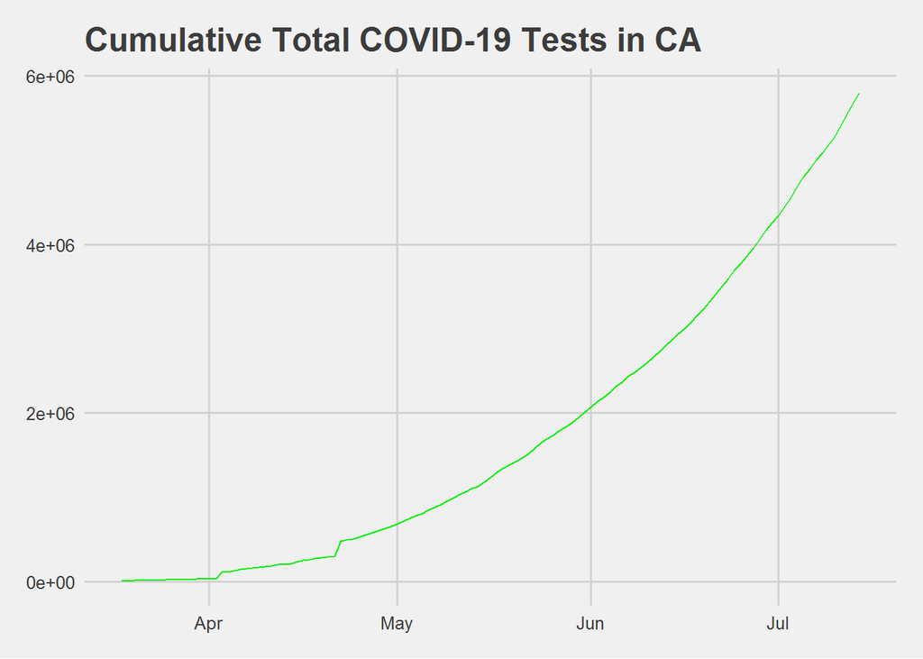

```r
#Cumulative total Tests
ggplot(data=CA, aes(x=date, y=testedtotal, group=1)) +
  geom_line(color="green2") + ggtitle("Cumulative Total COVID-19 Tests in CA") +
  scale_x_date(date_labels = "%b") + xlab("") + ylab("Count")+ theme_fivethirtyeight()
```

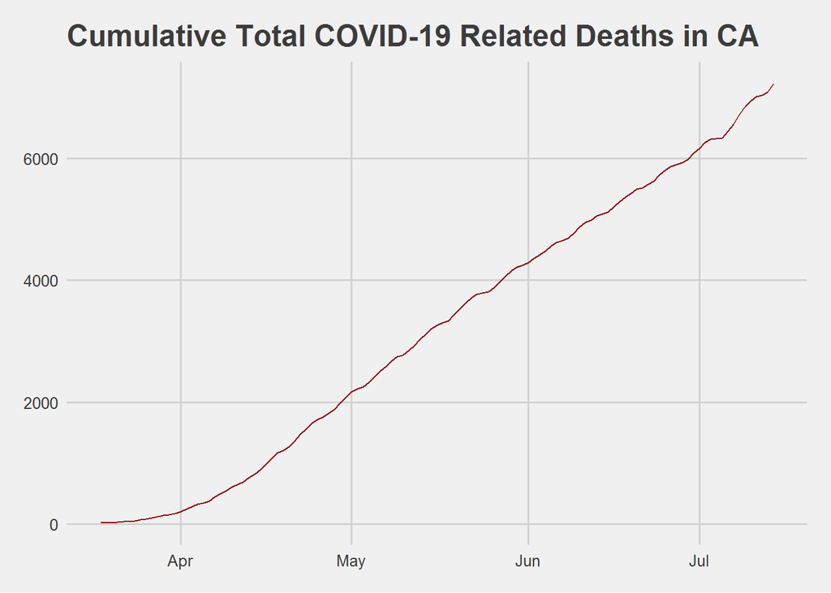

```r
#Cumulative total Deaths
ggplot(data=CA, aes(x=date, y=totalcountdeaths, group=1)) +
  geom_line(color="darkred") + ggtitle("Cumulative Total COVID-19 Related Deaths in CA") +
  scale_x_date(date_labels = "%b") + xlab("") + ylab("Count")+ theme_fivethirtyeight()
```

### California: Hospitalized Patients

As stated in the analysis of the US data, the number of hospitalized patients is a valuable metric for determining the impact of the virus over time as it represents the primary driving factor for policy making. is a The “hospitalized_covid_patients” category was not completely populated for the time frame that both confirmed and suspected hospitalizations data was available, so a new variable is created that calculates total hospitalized covid patients (confirmed + suspected).

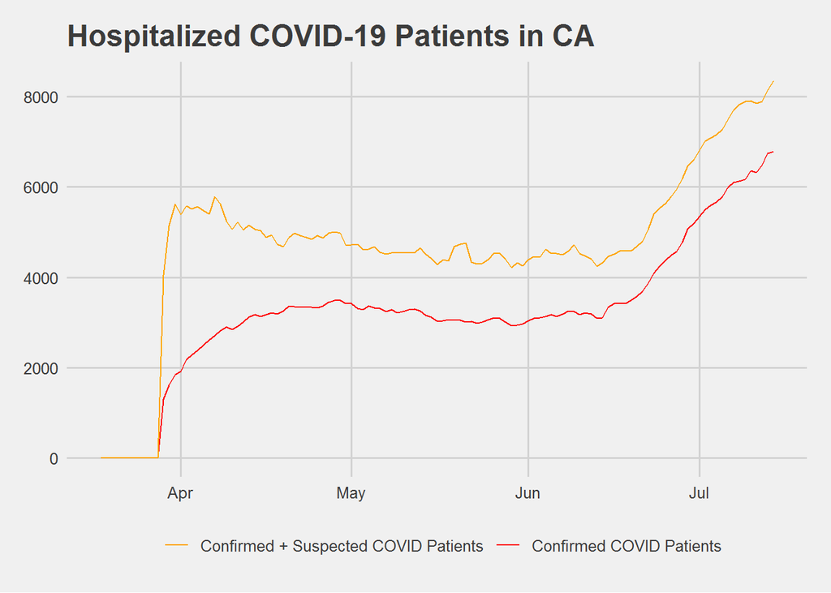

```r
Totalhosp <- (CA$hospitalized_covid_confirmed_patients + CA$hospitalized_suspected_covid_patients)

colors <- c("Confirmed COVID Patients" = "red", "Confirmed + Suspected COVID Patients" = "orange")
ggplot(data=CA) +
  geom_line(data=CA,aes(x=date, y=hospitalized_covid_confirmed_patients, color="Confirmed COVID Patients")) +
  geom_line(data=CA,aes(x=date, y=Totalhosp, color="Confirmed + Suspected COVID Patients")) +
  ggtitle("Hospitalized COVID-19 Patients in CA") +
  scale_x_date(date_labels = "%b") + labs(x="", y="Patients", color = "") +scale_color_manual(values = colors) +
  theme_fivethirtyeight()
```

Because the availability of tests has increased over time, using the total hospitalized patients (confirmed + suspected) might be the best representation even though there is a possibility that some suspected cases may not actually be COVID-related.

How does Hospitalization compare to new cases? New cases might be valuable in predicting hospitalization, or the realtionship between them could be informative in terms of the impact of the virus. Based on the plot below, there is an interesting pattern of cases making its way above the hospitalized patients curve, but it is reasonable to assume that currently hospitalizations rise as the number of daily new cases rises.

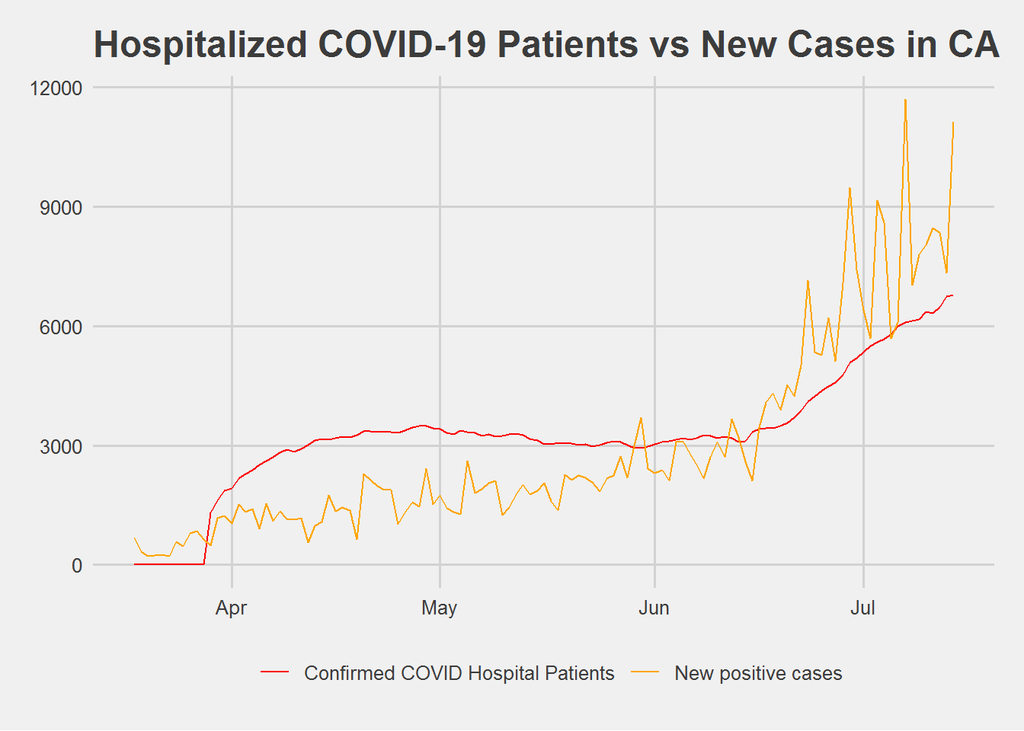

```r
colors <- c("Confirmed COVID Hospital Patients" = "red", "New positive cases" = "orange")
ggplot(data=CA) +
  geom_line(data=CA,aes(x=date, y=hospitalized_covid_confirmed_patients, color="Confirmed COVID Hospital Patients")) +
  geom_line(data=CA,aes(x=date, y=newcountconfirmed, color="New positive cases")) +
  ggtitle("Hospitalized COVID-19 Patients vs New Cases in CA") +
  scale_x_date(date_labels = "%b") + labs(x="", y="Patients", color = "") +scale_color_manual(values = colors) +
  theme_fivethirtyeight()
```

### California: Spectral Density Plots

The variable we are most interested in forecasting is Hospitalized Patients, so we check for any cyclic behavior that could be informative for model building.

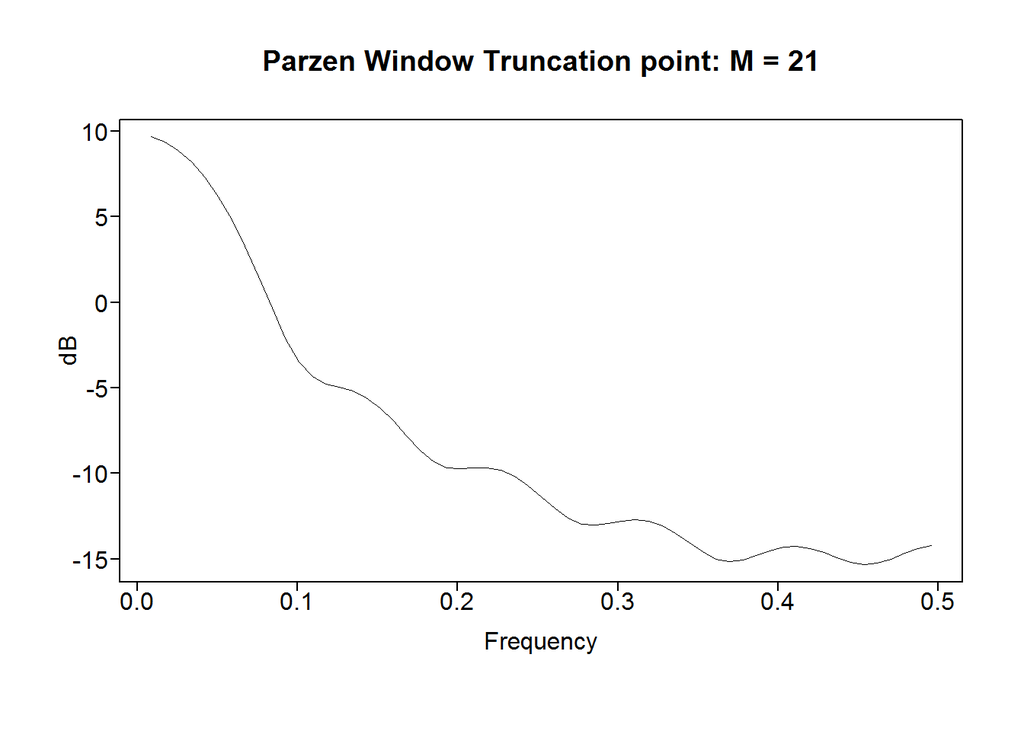

```r
parzen.wge(Totalhosp)
```

There are no non-zero peaks on the spectral density plot that are particularly revealing, but we may be interested later in only modeling the most recent upward trend (late June to present), so we can also check for any underlying cycles in that portion of the series by itself.

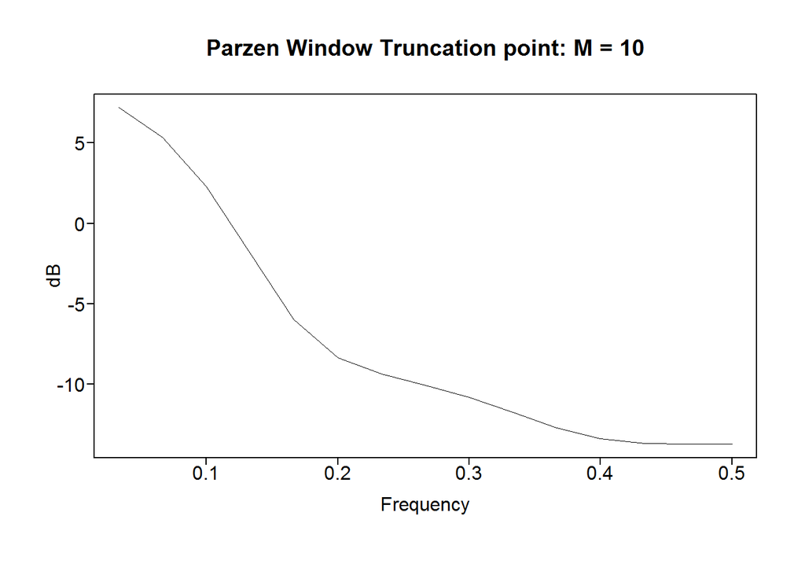

```r
Totalhosp2 <- Totalhosp[90:119] #This is only the hospitalized patients data from late June to present
parzen.wge(Totalhosp2)
```

There does not appear to be any cyclic behavior hiding in this time frame either.

### California: Stationary Model Estimation for COVID-related Hospitalizations

It is difficult to consider this data stationary in its own right due to the apparent dependence of hospitalized patients on time and non-constant variance (both attributable to the recent upward trend). We also know that the number started at zero (although it wasn’t tracked from that point in this dataset) and will, under the assumption that this is a novel virus, eventually end at zero. However, the use of a stationary model for prediction could be useful based on this knowledge of eventual decline, as its use would force a forecast back to the mean of the data we have.

#### Stationary models using the entire dataset

A model based on the top recommendation by AIC.

```r
#Estimate p and q
aic5.wge(Totalhosp)
```

```
## ---------WORKING... PLEASE WAIT...
##
##
## Five Smallest Values of  aic
```

```
##       p    q        aic
## 7     2    0   11.98731
## 6     1    2   11.99646
## 10    3    0   12.00066
## 8     2    1   12.00122
## 5     1    1   12.00350
```

```r
# aic5.wge(Totalhosp, type = "bic") this also resulted in recommending AR2

#Estimate phi and theta
Hosp_est <- est.ar.wge(Totalhosp, p=2, type = "burg")
```

```
##
## Coefficients of Original polynomial:
## 1.2538 -0.2885
##
## Factor                 Roots                Abs Recip    System Freq
## 1-0.9502B              1.0525               0.9502       0.0000
## 1-0.3037B              3.2930               0.3037       0.0000
##
##
```

```r
#one week forecast of AR2 model
f1 <- fore.arma.wge(Totalhosp, phi = Hosp_est$phi, n.ahead = 7, lastn = FALSE, limits = FALSE)
```

[figure not shown]

```r
#3 month Forecast of AR2 model
f1 <- fore.arma.wge(Totalhosp, phi = Hosp_est$phi, n.ahead = 90, lastn = FALSE, limits = FALSE)
```

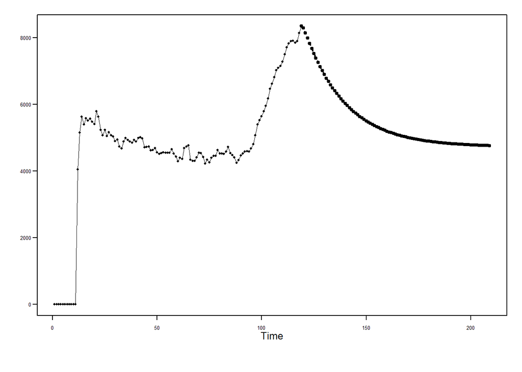

Another stationary model - ARMA(1,2) based on second suggestion from aic.wge.

```r
#Estimate phi and theta for an ARMA(1,2)
Hosp_estq <- est.arma.wge(Totalhosp, p=1,q=2) #AR component has a root very close to 1
```

```
##
## Coefficients of Original polynomial:
## 0.9779
##
## Factor                 Roots                Abs Recip    System Freq
## 1-0.9779B              1.0226               0.9779       0.0000
##
##
```

```r
#one week forecast of AR2 model
fq <- fore.arma.wge(Totalhosp, phi = Hosp_estq$phi, theta = Hosp_estq$theta, n.ahead = 7, lastn = FALSE, limits = FALSE)
```

[figure not shown]

```r
#3 month Forecast of AR2 model
fq <- fore.arma.wge(Totalhosp, phi = Hosp_estq$phi, theta = Hosp_estq$theta, n.ahead = 90, lastn = FALSE, limits = FALSE)
```

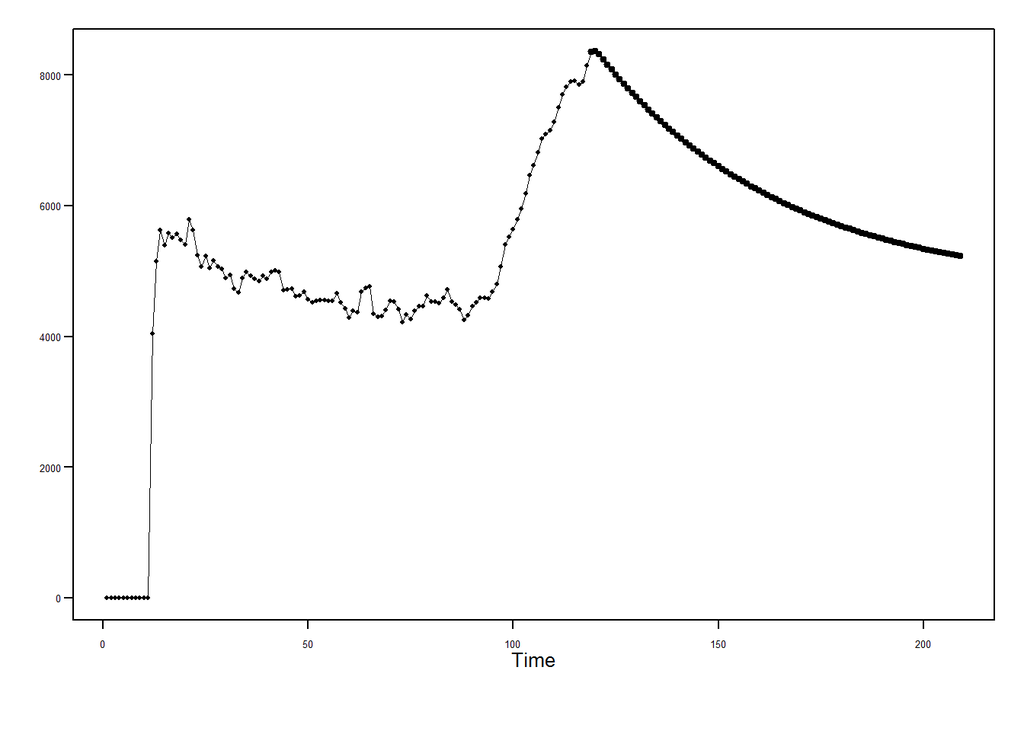

AIC of two stationary models above

```r
Hosp_est$aic
```

```
## [1] 11.97533
```

```r
Hosp_estq$aic
```

```
## [1] 11.99646
```

The AIC for the parameters of an AR(2) vs ARMA(1,2) model are nearly identical. We can use a windowed ASE to get a different comparison.

#### Windowed ASE evaluation of 2 stationary models

Model 1: AR(2)

```r
trainingSize = 90
horizon = 10
ASEHolder = numeric()

for( i in 1:(119-(trainingSize + horizon) + 1))
{

  forecasts = fore.aruma.wge(Totalhosp[i:(i+(trainingSize-1))],phi = Hosp_est$phi, n.ahead = horizon)

  ASE = mean((Totalhosp[(trainingSize+i):(trainingSize+ i + (horizon) - 1)] - forecasts$f)^2)

  ASEHolder[i] = ASE

}
```

```r
ASEHolder
hist(ASEHolder)
```

[output not shown]

```r
WindowedASE = mean(ASEHolder)

summary(ASEHolder)
```

[output not shown]

```r
WindowedASE
```

```
## [1] 1404948
```

Model 2: ARMA(1,2)

```r
trainingSize = 90
horizon = 10
ASEHolder = numeric()

for( i in 1:(119-(trainingSize + horizon) + 1))
{

  forecasts = fore.aruma.wge(Totalhosp[i:(i+(trainingSize-1))],phi = Hosp_estq$phi, theta = Hosp_estq$theta, n.ahead = horizon)

  ASE = mean((Totalhosp[(trainingSize+i):(trainingSize+ i + (horizon) - 1)] - forecasts$f)^2)

  ASEHolder[i] = ASE

}
```

```r
ASEHolder
hist(ASEHolder)
```

[output not shown]

```r
WindowedASE = mean(ASEHolder)

summary(ASEHolder)
```

[output not shown]

```r
WindowedASE
```

```
## [1] 1100078
```

The ARMA(1,2) model has a lower ASE when using the windowed ASE method to compare the 2 models. The windowed ASE might be a better indicator because the behavior of the data changes over the course of the realization. This model also has some appeal to its behavior of increasing for a couple points before making its decline.

```r
Hosp_estq$phi #phi coefficients
```

```
## [1] 0.9779335
```

```r
Hosp_estq$theta #theta coefficients
```

```
## [1] -0.2919636 -0.1422741
```

```r
Hosp_estq$avar #white noise variance estimate
```

```
## [1] 151635.6
```

```r
mean(Totalhosp) #mean
```

```
## [1] 4722.504
```

What this means to us: Stationary models like these are useful only if it is believed that the count is going to (almost) immediately begin its decline toward the mean of the data we have (the ARMA(1,2) model has a slight increase first). Whether an imminent decline is likely or not is anyone’s guess, but based on the apparent trend in the short term, we might not consider that to be realistic for a 7 day forecast. What we do know is that the count does have to come down at some point, and for a 90 day forecast this model could be a guess that takes into account our knowledge of this assumption of eventual decrease. It could be reasonable to assume that the number of hospitalizations will make its way down to the average number seen in the previous few months before eventually falling further later.

### California: Non-Stationary Model Estimation for COVID-related Hospitalizations

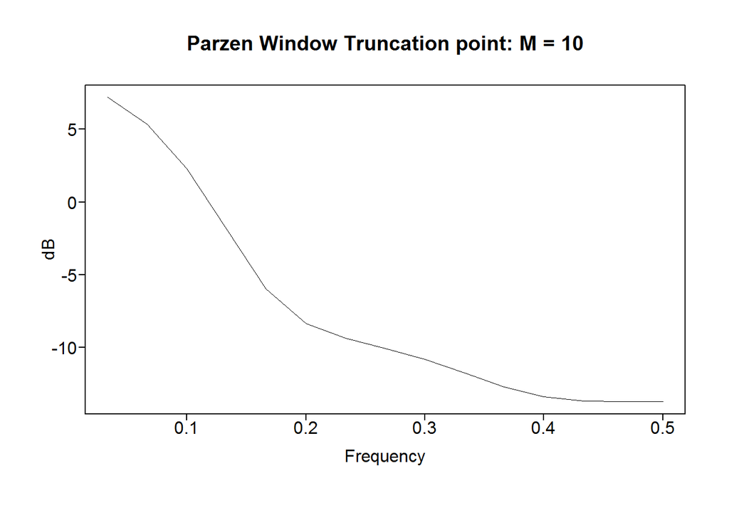

```
## $freq
##  [1] 0.03333333 0.06666667 0.10000000 0.13333333 0.16666667 0.20000000
##  [7] 0.23333333 0.26666667 0.30000000 0.33333333 0.36666667 0.40000000
## [13] 0.43333333 0.46666667 0.50000000
##
## $pzgram
##  [1]   7.188782   5.362028   2.294521  -1.834998  -5.976450  -8.355991
##  [7]  -9.368897 -10.072105 -10.810343 -11.742140 -12.694657 -13.357756
## [13] -13.658033 -13.711666 -13.696568
```

```r
Totalhosp2 <- Totalhosp[90:119] #This is only the hospitalized patients data from late June to present
parzen.wge(Totalhosp2)
```

```r
#Differencing the data: We want a second difference so that the current trend will continue
Totalhosp2_d1 <- artrans.wge(Totalhosp2, phi.tr = 1) #acf makes it look like there might be a cycle
```

[figure not shown]

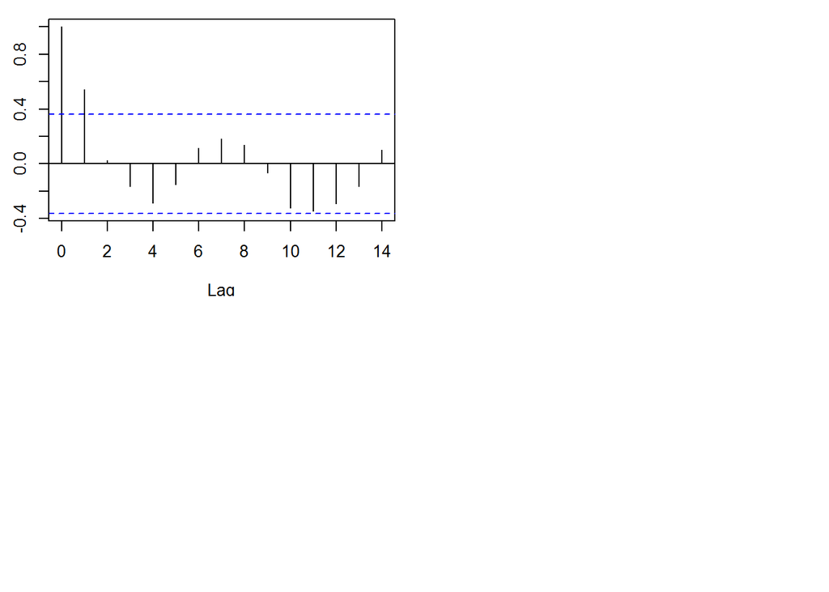

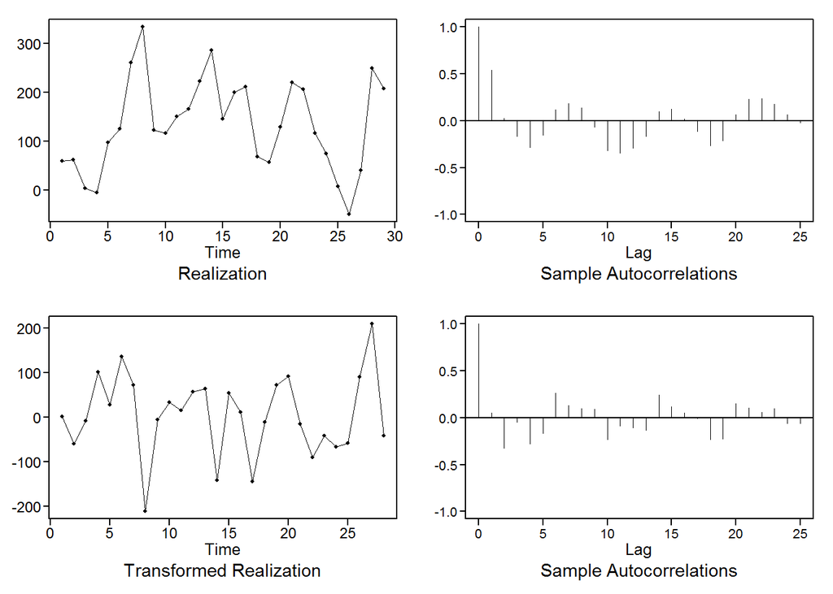

```r
acf(Totalhosp2_d1) # the "cycle" is not significant
Totalhosp2_d2 <- artrans.wge(Totalhosp2_d1, phi.tr = 1) #acf plot looks like it might not be white noise
```

```r
acf(Totalhosp2_d2, lag.max = 30) #based on conf limits ...it is white noise
ljung.wge(Totalhosp2_d2, K=12)$pval #Fewer data points to work with - lower K.
```

```
## Obs 0.04877171 -0.3273048 -0.04821564 -0.2798323 -0.1626644 0.2627508 0.1299537 0.09551154 0.09048474 -0.22975 -0.0883593 -0.1085316
```

```
## [1] 0.2500581
```

```r
ljung.wge(Totalhosp2_d2, K=25)$pval #both FTR.
```

```
## Obs 0.04877171 -0.3273048 -0.04821564 -0.2798323 -0.1626644 0.2627508 0.1299537 0.09551154 0.09048474 -0.22975 -0.0883593 -0.1085316 -0.1357074 0.2410103 0.1213577 0.05148187 -0.010668 -0.2349942 -0.2263963 0.1526814 0.1067805 0.05623022 0.09902656 -0.05716637 -0.05792681
```

```
## [1] 0.05216961
```

[figure not shown]

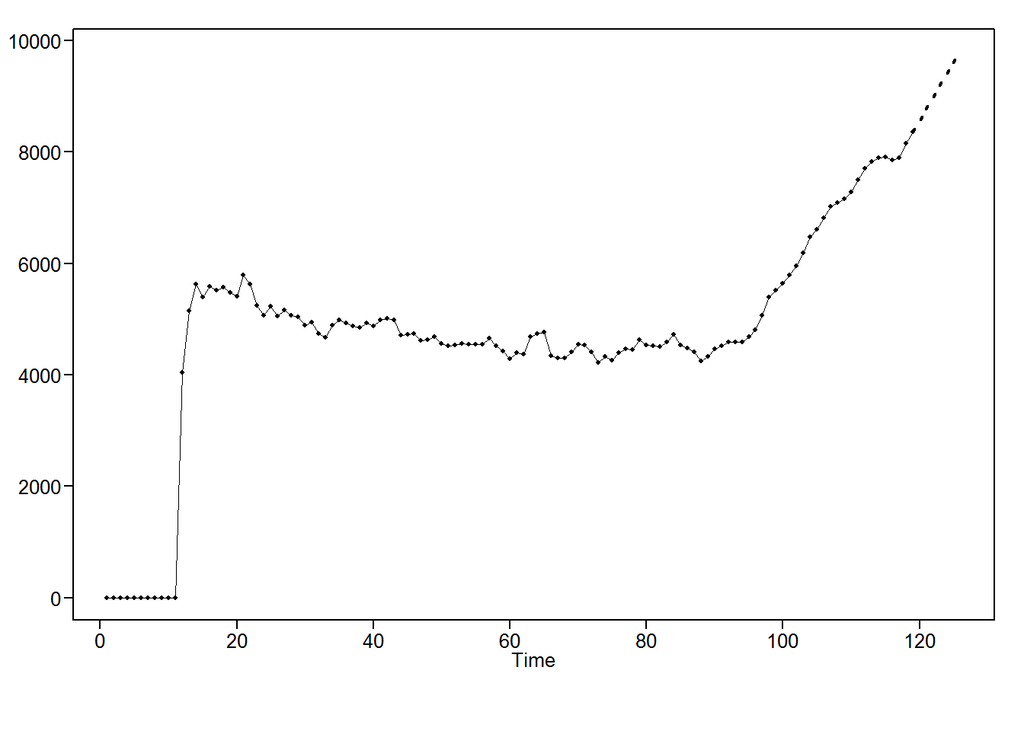

```r
#The resulting realization, ACF plot, and ljung- Box test suggest that the diff data is white noise; no need to fit the differenced data.

#The final model is a simple ARIMA(0,0,0) with d=2
f2 <- fore.aruma.wge(Totalhosp, d=2, n.ahead = 7, lastn = FALSE, limits = FALSE)
```

We can take a closer look at what the 7 day forecast looks like for just the trend we’ve seen in the past month. This seems like a reasonable expectation for the next week, but we would not use this to predict much further than that.

```r
f2c <- fore.aruma.wge(Totalhosp2, d=2, n.ahead = 7, lastn = FALSE, limits = FALSE)
```

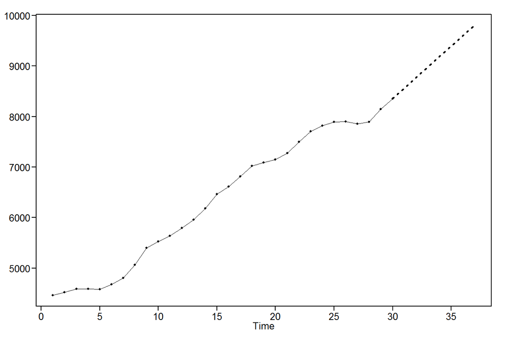